# wrangle_act

## Introduction

### For this Data Wrangling exercise, I'm going to use a file containing previously pulled archived Tweets from @WeRateDogs twitter handle. Then I'm going to use the requests library to download a previously saved Image prediction file. Also, I'll be using Twitter's API to pull the tweet details like, Retweet counts and Favorite counts to analyze the data.

```python
import pandas as pd
import numpy as np
import requests as rq
import json as js
```

```python
import tweepy
```

```python
consumer_key = 'consumer_key'
consumer_secret = 'consumer_secret'
access_token = 'access_token'
access_secret = 'access_secret'

auth = tweepy.OAuthHandler(consumer_key, consumer_secret)
auth.set_access_token(access_token, access_secret)

#api = tweepy.API(auth)
api = tweepy.API(auth_handler=auth, wait_on_rate_limit=True, wait_on_rate_limit_notify=True)
```

```python
from __future__ import print_function
import getopt
import logging
import os
import sys
```

```python
import requests
```

```python
import tweepy
from tweepy import OAuthHandler
import json
from timeit import default_timer as timer
```

# GATHER

### Archived tweets using Twiiter API

### Code

**Pull All the tweets from twitter archive and store it in tweet_json.txt file**

```python
len(tweet_ids)

# Query Twitter's API for JSON data for each tweet ID in the Twitter archive
count = 0
fails_dict = {}
start = timer()
# Save each tweet's returned JSON as a new line in a .txt file
with open('tweet_json.txt', 'w') as outfile:
    # This loop will likely take 20-30 minutes to run because of Twitter's rate limit
    for tweet_id in tweet_ids:
        count += 1
        print(str(count) + ": " + str(tweet_id))
        try:
            tweet = api.get_status(tweet_id, tweet_mode='extended')
            print("Success")
            json.dump(tweet._json, outfile)
            outfile.write('\n')
        except tweepy.TweepError as e:
            print("Fail")
            fails_dict[tweet_id] = e
            pass
end = timer()
print(end - start)
print(fails_dict)
```

[output not shown]

[output cut: 1744 more lines]

[output not shown]

```
Rate limit reached. Sleeping for: 316
```

[output not shown]

[output cut: 1745 more lines]

[output not shown]

```
Rate limit reached. Sleeping for: 398
```

[output not shown]

[output cut: 498 more lines]

[output not shown]

### Code

**Read the json from the file and create a dataframe**

```python
all_data=[]
my_demo_list = []
for json_file in open('tweet_json.txt', encoding='utf-8'):
    all_data.append(json.loads(json_file))
```

```python
for each_dictionary in all_data:
        tweet_id = each_dictionary['id']
        text = each_dictionary['full_text']
        favorite_count = each_dictionary['favorite_count']
        retweet_count = each_dictionary['retweet_count']
        created_at = each_dictionary['created_at']
        my_demo_list.append({'tweet_id': str(tweet_id),
                             'text': str(text),
                             'favorite_count': int(favorite_count),
                             'retweet_count': int(retweet_count),
                             'created_at': created_at,
                            })
        #print(my_demo_list)
        tweet_json = pd.DataFrame(my_demo_list, columns =
                                  ['tweet_id', 'text',
                                   'favorite_count', 'retweet_count',
                                   'created_at'])
```

```python
tweet_json.head(2)
```

|  | tweet_id | text | favorite_count | retweet_count | created_at |
| --- | --- | --- | --- | --- | --- |
| 0 | 666020888022790149 | Here we have a Japanese Irish Setter. Lost eye... | 2385 | 458 | Sun Nov 15 22:32:08 +0000 2015 |
| 1 | 666029285002620928 | This is a western brown Mitsubishi terrier. Up... | 120 | 42 | Sun Nov 15 23:05:30 +0000 2015 |

```python
tweet_json.info()
```

```
<class 'pandas.core.frame.DataFrame'>
RangeIndex: 2059 entries, 0 to 2058
Data columns (total 5 columns):
tweet_id          2059 non-null object
text              2059 non-null object
favorite_count    2059 non-null int64
retweet_count     2059 non-null int64
created_at        2059 non-null object
dtypes: int64(2), object(3)
memory usage: 80.6+ KB
```

## Clean

```python
tweet_json_clean = tweet_json.copy()
```

### Define

##### 1. Change the tweet_id datatype to Int64

### Code

```python
#change ID format to join it with Twitter_data
tweet_json_clean.tweet_id = tweet_json_clean.tweet_id.astype(np.int64)
```

### Test

```python
tweet_json_clean.info()
```

```
<class 'pandas.core.frame.DataFrame'>
RangeIndex: 2059 entries, 0 to 2058
Data columns (total 5 columns):
tweet_id          2059 non-null int64
text              2059 non-null object
favorite_count    2059 non-null int64
retweet_count     2059 non-null int64
created_at        2059 non-null object
dtypes: int64(3), object(2)
memory usage: 80.6+ KB
```

# GATHER

**Now, read the "twitter-archive-enhanced" file (which has all the archived tweets from @WeRateDogs handle) into a dataframe**

```python
twitter_data = pd.read_csv('./twitter-archive-enhanced.csv')
twitter_data.head(2)
```

|  | tweet_id | in_reply_to_status_id | in_reply_to_user_id | timestamp | source | text | retweeted_status_id | retweeted_status_user_id | retweeted_status_timestamp | expanded_urls | rating_numerator | rating_denominator | name | doggo | floofer | pupper | puppo |
| --- | --- | --- | --- | --- | --- | --- | --- | --- | --- | --- | --- | --- | --- | --- | --- | --- | --- |
| 0 | 892420643555336193 | NaN | NaN | 2017-08-01 16:23:56 +0000 | <a href="http://twitter.com/download/iphone" r... | This is Phineas. He's a mystical boy. Only eve... | NaN | NaN | NaN | https://twitter.com/dog_rates/status/892420643... | 13 | 10 | Phineas | None | None | None | None |
| 1 | 892177421306343426 | NaN | NaN | 2017-08-01 00:17:27 +0000 | <a href="http://twitter.com/download/iphone" r... | This is Tilly. She's just checking pup on you.... | NaN | NaN | NaN | https://twitter.com/dog_rates/status/892177421... | 13 | 10 | Tilly | None | None | None | None |

## Clean

```python
twitter_data_clean= twitter_data.copy()
```

### Define

**1. Combine the 4 Dog stages fields into one and drop the 4 fields**

**2. Drop Retweets and Replies from Twitter_data and save it to "twitter_data_clean" dataframe**

**3. Remove unwanted columns from the Dataframe**

**4.Clean-up Ratings. (Make sure Rating Denominator is a multiple of 10; if not see if a wrong rating was picked up and clean it up)**

```
    4a. Remove record if a rating is not available ( 1 record found)
    4b. Pick the correct Ratings if available. (3 records fond. Mostly the last 4 characters in the tweet cotains
    correct ratings)
```

**5. Apparently, the Archived dataset has not captured the ratings with a decimal point, let's clean it up.**

**6. When the Rating denominatior is more than 10 (multiple dogs rates in the same tweet), lets's take an average out of Ten so that We can easily pot the Numerators to seee trends.**

### Code

**1. Combine the 4 Dog stages fields into one and drop the 4 fields**

```python
# handle none
twitter_data_clean.doggo.replace('None', '', inplace=True)
twitter_data_clean.floofer.replace('None', '', inplace=True)
twitter_data_clean.pupper.replace('None', '', inplace=True)
twitter_data_clean.puppo.replace('None', '', inplace=True)

# merge into column
twitter_data_clean['dog_stage'] = twitter_data_clean.doggo + twitter_data_clean.floofer + twitter_data_clean.pupper + twitter_data_clean.puppo

# handle multiple stages
twitter_data_clean.loc[twitter_data_clean.dog_stage == 'doggopupper', 'dog_stage'] = 'doggo, pupper'
twitter_data_clean.loc[twitter_data_clean.dog_stage == 'doggopuppo', 'dog_stage'] = 'doggo, puppo'
twitter_data_clean.loc[twitter_data_clean.dog_stage == 'doggofloofer', 'dog_stage'] = 'doggo, floofer'

# handle missing values
twitter_data_clean.loc[twitter_data_clean.dog_stage == '', 'dog_stage'] = np.nan
```

**2. Drop Retweets and Replies from Twitter_data and save it to "twitter_data_clean" dataframe**

```python
# Drop Retweets
twitter_data_clean = twitter_data_clean[~twitter_data.text.str.startswith("RT @")]
```

```python
# Drop Replies
twitter_data_clean = twitter_data_clean[~twitter_data_clean.in_reply_to_status_id.notnull()]
```

**3. Drop unwanted columns from the dataframe**

```python
twitter_data_clean = twitter_data_clean[['tweet_id','timestamp','text','expanded_urls','rating_numerator','rating_denominator','name','dog_stage']]
twitter_data_clean.head(2)
```

|  | tweet_id | timestamp | text | expanded_urls | rating_numerator | rating_denominator | name | dog_stage |
| --- | --- | --- | --- | --- | --- | --- | --- | --- |
| 0 | 892420643555336193 | 2017-08-01 16:23:56 +0000 | This is Phineas. He's a mystical boy. Only eve... | https://twitter.com/dog_rates/status/892420643... | 13 | 10 | Phineas | NaN |
| 1 | 892177421306343426 | 2017-08-01 00:17:27 +0000 | This is Tilly. She's just checking pup on you.... | https://twitter.com/dog_rates/status/892177421... | 13 | 10 | Tilly | NaN |

**4.Clean-up Ratings**

```python
#Pick the tweets that don't have a Rating denominator as a multiple of 10 and save it in a new DF
twitter_data_clean_denom =twitter_data_clean[twitter_data_clean["rating_denominator"]!=10]
twitter_data_clean_denom = twitter_data_clean_denom[twitter_data_clean_denom.rating_denominator%10 !=0]

#Strip out the second set of numbers in the string eg. 14/10 instead of 7/11
twitter_data_clean_denom['new_rating'] = twitter_data_clean_denom.text.str.findall(r"\d+\d*\/\d+.*?(\d+\d*\/\d+)",).transform(''.join)

#Assign the new values to the Numerator and Denominator columns.

twitter_data_clean_denom["rating_numerator"] = twitter_data_clean_denom["new_rating"].str.split("/",expand=True)[0].apply(pd.to_numeric)
twitter_data_clean_denom["rating_denominator"] = twitter_data_clean_denom["new_rating"].str.split("/",expand=True)[1].apply(pd.to_numeric)
```

```python
#Assign the cleaned up Rating values to main twitter_data_clean dataframe columns.

twitter_data_clean.loc[twitter_data_clean.tweet_id.isin(twitter_data_clean_denom.tweet_id), ['rating_numerator','rating_denominator']]\
= twitter_data_clean_denom[['rating_numerator','rating_denominator']]

#Remove one records with no clean rating
twitter_data_clean = twitter_data_clean[twitter_data_clean['rating_denominator'].isnull()==False]

twitter_data_clean[['rating_numerator','rating_denominator']] =twitter_data_clean[['rating_numerator','rating_denominator']].apply(pd.to_numeric)

#this should not return any record
twitter_data_clean[twitter_data_clean.rating_denominator%10 !=0]
```

|  | tweet_id | timestamp | text | expanded_urls | rating_numerator | rating_denominator | name | dog_stage |
| --- | --- | --- | --- | --- | --- | --- | --- | --- |

**5. Apparently, the Archived dataset has not captured the ratings with a decimal point, let's clean it up.**

```python
twitter_data_clean_rating = twitter_data_clean.copy()
twitter_data_clean_rating["new_field"] = twitter_data_clean_fractions.text.str.findall(r"(\d+\.\d*\/\d+)",).transform(''.join)

twitter_data_clean_rating = twitter_data_clean_rating[twitter_data_clean_rating.new_field !='']

twitter_data_clean_rating["rating_numerator"] = twitter_data_clean_rating["new_field"].str.split("/",expand=True)[0].apply(pd.to_numeric)
```

```python
#Assign the cleaned up Rating values to main twitter_data_clean dataframe columns.

twitter_data_clean.loc[twitter_data_clean.tweet_id.isin(twitter_data_clean_rating.tweet_id), ['rating_numerator','rating_denominator']]\
= twitter_data_clean_rating[['rating_numerator','rating_denominator']]

twitter_data_clean['rating_numerator'] =twitter_data_clean['rating_numerator'].apply(pd.to_numeric)
```

```python
#Make the Ratings Consistent (out of 10)
#e.g. if the rating is 60/40, make it 15/10. when it's 11/10 leave it as is. The folowing logic should get us there.
twitter_data_clean.rating_numerator = twitter_data_clean.rating_numerator / (twitter_data_clean.rating_denominator / 10)
twitter_data_clean[twitter_data_clean.rating_denominator!=10].head(2)
```

|  | tweet_id | timestamp | text | expanded_urls | rating_numerator | rating_denominator | name | dog_stage |
| --- | --- | --- | --- | --- | --- | --- | --- | --- |
| 433 | 820690176645140481 | 2017-01-15 17:52:40 +0000 | The floofs have been released I repeat the flo... | https://twitter.com/dog_rates/status/820690176... | 12.0 | 70.0 | None | NaN |
| 902 | 758467244762497024 | 2016-07-28 01:00:57 +0000 | Why does this never happen at my front door...... | https://twitter.com/dog_rates/status/758467244... | 11.0 | 150.0 | None | NaN |

```python
#Now we can make all the Denominator 10
twitter_data_clean.rating_denominator = 10
```

### Test

```python
twitter_data_clean.describe()
```

|  | tweet_id | rating_numerator | rating_denominator |
| --- | --- | --- | --- |
| count | 2.096000e+03 | 2096.000000 | 2096.0 |
| mean | 7.365239e+17 | 11.646842 | 10.0 |
| std | 6.709809e+16 | 39.638275 | 0.0 |
| min | 6.660209e+17 | 0.000000 | 10.0 |
| 25% | 6.768177e+17 | 10.000000 | 10.0 |
| 50% | 7.097095e+17 | 11.000000 | 10.0 |
| 75% | 7.874779e+17 | 12.000000 | 10.0 |
| max | 8.924206e+17 | 1776.000000 | 10.0 |

```python
twitter_data_clean.isnull()
```

|  | tweet_id | timestamp | text | expanded_urls | rating_numerator | rating_denominator | name | dog_stage |
| --- | --- | --- | --- | --- | --- | --- | --- | --- |
| 0 | False | False | False | False | False | False | False | True |
| 1 | False | False | False | False | False | False | False | True |
| 2 | False | False | False | False | False | False | False | True |
| 3 | False | False | False | False | False | False | False | True |
| 4 | False | False | False | False | False | False | False | True |
| ... | ... | ... | ... | ... | ... | ... | ... | ... |
| 2351 | False | False | False | False | False | False | False | True |
| 2352 | False | False | False | False | False | False | False | True |
| 2353 | False | False | False | False | False | False | False | True |
| 2354 | False | False | False | False | False | False | False | True |
| 2355 | False | False | False | False | False | False | False | True |

2096 rows × 8 columns

```python
twitter_data_clean.head(2)
```

|  | tweet_id | timestamp | text | expanded_urls | rating_numerator | rating_denominator | name | dog_stage |
| --- | --- | --- | --- | --- | --- | --- | --- | --- |
| 0 | 892420643555336193 | 2017-08-01 16:23:56 +0000 | This is Phineas. He's a mystical boy. Only eve... | https://twitter.com/dog_rates/status/892420643... | 13.0 | 10 | Phineas | NaN |
| 1 | 892177421306343426 | 2017-08-01 00:17:27 +0000 | This is Tilly. She's just checking pup on you.... | https://twitter.com/dog_rates/status/892177421... | 13.0 | 10 | Tilly | NaN |

## GATHER

**Get the image Predition File using requests library**

```python
r = requests.get('https://d17h27t6h515a5.cloudfront.net/topher/2017/August/599fd2ad_image-predictions/image-predictions.tsv', auth=('user', 'pass'))
```

```python
r.status_code
```

```
200
```

```python
r.headers['content-type']
```

```
'text/tab-separated-values; charset=utf-8'
```

```python
r.encoding
```

```
'utf-8'
```

```python
import csv
df=pd.DataFrame()
wrapper = csv.reader(r.text.strip().split('\n'))
list_of_tuples = list(map(tuple, wrapper))
```

```python
list_of_tuples[0]
```

```
('tweet_id\tjpg_url\timg_num\tp1\tp1_conf\tp1_dog\tp2\tp2_conf\tp2_dog\tp3\tp3_conf\tp3_dog',)
```

```python
img_prediction = pd.DataFrame(list(list_of_tuples))
img_prediction.head(2)
```

|  | 0 |
| --- | --- |
| 0 | tweet_id\tjpg_url\timg_num\tp1\tp1_conf\tp1_do... |
| 1 | 666020888022790149\thttps://pbs.twimg.com/medi... |

```python
img_prediction = img_prediction[0].str.split('\t',expand=True)
```

```python
new_header = img_prediction.iloc[0] #grab the first row for the header
img_prediction = img_prediction[1:] #take the data less the header row
img_prediction.columns = new_header
```

```python
img_prediction.head(2)
```

|  | tweet_id | jpg_url | img_num | p1 | p1_conf | p1_dog | p2 | p2_conf | p2_dog | p3 | p3_conf | p3_dog |
| --- | --- | --- | --- | --- | --- | --- | --- | --- | --- | --- | --- | --- |
| 1 | 666020888022790149 | https://pbs.twimg.com/media/CT4udn0WwAA0aMy.jpg | 1 | Welsh_springer_spaniel | 0.465074 | True | collie | 0.156665 | True | Shetland_sheepdog | 0.0614285 | True |
| 2 | 666029285002620928 | https://pbs.twimg.com/media/CT42GRgUYAA5iDo.jpg | 1 | redbone | 0.506826 | True | miniature_pinscher | 0.07419169999999999 | True | Rhodesian_ridgeback | 0.07201 | True |

**Look at a sample tweet**

```python
tweet = api.get_status(671768281401958400)
print(tweet.text)
```

```
When you try to recreate the scene from Lady &amp; The Tramp but then remember you don't have a significant other. 10/10 https://t.co/TASnD8Q08S
```

```python
#Check one Tweet
img_prediction[img_prediction.tweet_id=="671768281401958400"]
```

|  | tweet_id | jpg_url | img_num | p1 | p1_conf | p1_dog | p2 | p2_conf | p2_dog | p3 | p3_conf | p3_dog |
| --- | --- | --- | --- | --- | --- | --- | --- | --- | --- | --- | --- | --- |
| 320 | 671768281401958400 | https://pbs.twimg.com/media/CVKZsHtWwAA6gPj.jpg | 2 | Chihuahua | 0.500373 | True | French_bulldog | 0.11279600000000001 | True | Italian_greyhound | 0.0628927 | True |

## Clean

```python
img_prediction_clean = img_prediction.copy()
```

### Define

**1. Transpose (Make the prediction into one column instead of multiple columns) the Predicted fields to make the data cleaner and easier to use.**

### Code

**1. Transpose (Make the prediction into one clumn instead of multiple columns) the Predicted fields to make the data cleaner and easier to use.**

**2. Remove wrong/False prediction (e.g. in one instance "paper Towel" was predicted as a dog breed.)**

**3. Remove Duplicates**

**4. Keep the highest Prediction confidence record for each Image. Drop rest of the records.**

```python
#Transpose P1, P2, P3 (Breed Predition) Columns into one column "pred_val"
img_prediction_clean_melt1 = pd.melt(img_prediction_clean, id_vars=['tweet_id', 'jpg_url', 'img_num'],
                           value_vars=['p1','p2','p3'], var_name='prediction', value_name='pred_val')

#Transpose 'p1_conf','p2_conf','p3_conf' (Predition confidence) Columns into one column "pred_conf"
img_prediction_clean_melt2 = pd.melt(img_prediction_clean, id_vars=['tweet_id', 'jpg_url', 'img_num'],
                           value_vars=['p1_conf','p2_conf','p3_conf'], var_name='prediction', value_name='pred_conf')
img_prediction_clean_melt2.prediction = img_prediction_clean_melt2.prediction.str[:2]

#Transpose 'p1_dog','p3_dog','p3_dog' (Predition truthfulness) Columns into one column "pred_accuracy"
img_prediction_clean_melt3 = pd.melt(img_prediction, id_vars=['tweet_id', 'jpg_url', 'img_num'],
                           value_vars=['p1_dog','p3_dog','p3_dog'], var_name='prediction', value_name='pred_accuracy')

img_prediction_clean_melt3.prediction = img_prediction_clean_melt3.prediction.str[:2]
```

```python
#Merge Three Melted Data Frames into one

img_prediction_clean_melt = img_prediction_clean_melt1.merge(img_prediction_clean_melt2,on=['tweet_id','img_num','jpg_url','prediction'])
img_prediction_clean_melt = img_prediction_clean_melt.merge(img_prediction_clean_melt3,on=['tweet_id','img_num','jpg_url','prediction'])
```

```python
#Test
img_prediction_clean_melt.head(5)
```

|  | tweet_id | jpg_url | img_num | prediction | pred_val | pred_conf | pred_accuracy |
| --- | --- | --- | --- | --- | --- | --- | --- |
| 0 | 666020888022790149 | https://pbs.twimg.com/media/CT4udn0WwAA0aMy.jpg | 1 | p1 | Welsh_springer_spaniel | 0.465074 | True |
| 1 | 666029285002620928 | https://pbs.twimg.com/media/CT42GRgUYAA5iDo.jpg | 1 | p1 | redbone | 0.506826 | True |
| 2 | 666033412701032449 | https://pbs.twimg.com/media/CT4521TWwAEvMyu.jpg | 1 | p1 | German_shepherd | 0.596461 | True |
| 3 | 666044226329800704 | https://pbs.twimg.com/media/CT5Dr8HUEAA-lEu.jpg | 1 | p1 | Rhodesian_ridgeback | 0.408143 | True |
| 4 | 666049248165822465 | https://pbs.twimg.com/media/CT5IQmsXIAAKY4A.jpg | 1 | p1 | miniature_pinscher | 0.560311 | True |

**2. Removing wrong/False prediction (e.g. in one instance "paper Towel" was predicted as a dog breed.)**

```python
img_prediction_clean_melt = img_prediction_clean_melt[img_prediction_clean_melt.pred_accuracy=='True']
img_prediction_clean_melt.shape
```

```
(4530, 7)
```

**3. Remove Duplicates**

```python
#Remove duplicate records
img_prediction_clean_melt = img_prediction_clean_melt.drop_duplicates()
img_prediction_clean_melt.shape
```

```
(3031, 7)
```

```python
img_prediction_clean_melt.to_csv("./img_prediction_clean_melt.csv")
```

**4. Keep the top record by predicted values and drop rest of the rows for each image/tweet**

```python
#Group by 'tweet_id', 'jpg_url', 'img_num','prediction'
grouped = img_prediction_clean_melt.groupby(['tweet_id', 'jpg_url', 'img_num','prediction']).max().sort_values('pred_conf', ascending=False).reset_index()

#Sort by pred_conf descending to keep the highest rated predictions at the top for each Tweets
#grouped_sorted = grouped.sort_values('pred_conf', ascending=False)

#Keep the first record of every tweet and drop the rest. Save it back to the Clean Dataframe
img_prediction_clean = grouped.groupby(['tweet_id', 'jpg_url', 'img_num']).first().reset_index()
img_prediction_clean.head(5)
```

|  | tweet_id | jpg_url | img_num | prediction | pred_val | pred_conf | pred_accuracy |
| --- | --- | --- | --- | --- | --- | --- | --- |
| 0 | 666020888022790149 | https://pbs.twimg.com/media/CT4udn0WwAA0aMy.jpg | 1 | p1 | Welsh_springer_spaniel | 0.465074 | True |
| 1 | 666029285002620928 | https://pbs.twimg.com/media/CT42GRgUYAA5iDo.jpg | 1 | p1 | redbone | 0.506826 | True |
| 2 | 666033412701032449 | https://pbs.twimg.com/media/CT4521TWwAEvMyu.jpg | 1 | p1 | German_shepherd | 0.596461 | True |
| 3 | 666044226329800704 | https://pbs.twimg.com/media/CT5Dr8HUEAA-lEu.jpg | 1 | p1 | Rhodesian_ridgeback | 0.408143 | True |
| 4 | 666049248165822465 | https://pbs.twimg.com/media/CT5IQmsXIAAKY4A.jpg | 1 | p1 | miniature_pinscher | 0.560311 | True |

```python
#Save data and investigate
img_prediction_clean_melt.to_csv("./img_prediction_clean.csv")
```

### Test

```python
img_prediction_clean.head(2)
```

|  | tweet_id | jpg_url | img_num | prediction | pred_val | pred_conf | pred_accuracy |
| --- | --- | --- | --- | --- | --- | --- | --- |
| 0 | 666020888022790149 | https://pbs.twimg.com/media/CT4udn0WwAA0aMy.jpg | 1 | p1 | Welsh_springer_spaniel | 0.465074 | True |
| 1 | 666029285002620928 | https://pbs.twimg.com/media/CT42GRgUYAA5iDo.jpg | 1 | p1 | redbone | 0.506826 | True |

```python
#Test for Dups
img_prediction_clean.tweet_id.nunique()
```

```
1697
```

```python
#test
img_prediction_clean[img_prediction_clean.tweet_id=="671768281401958400"]
```

|  | tweet_id | jpg_url | img_num | prediction | pred_val | pred_conf | pred_accuracy |
| --- | --- | --- | --- | --- | --- | --- | --- |
| 228 | 671768281401958400 | https://pbs.twimg.com/media/CVKZsHtWwAA6gPj.jpg | 2 | p1 | Chihuahua | 0.500373 | True |

```python
img_prediction_clean.head(2)
```

|  | tweet_id | jpg_url | img_num | prediction | pred_val | pred_conf | pred_accuracy |
| --- | --- | --- | --- | --- | --- | --- | --- |
| 0 | 666020888022790149 | https://pbs.twimg.com/media/CT4udn0WwAA0aMy.jpg | 1 | p1 | Welsh_springer_spaniel | 0.465074 | True |
| 1 | 666029285002620928 | https://pbs.twimg.com/media/CT42GRgUYAA5iDo.jpg | 1 | p1 | redbone | 0.506826 | True |

## Define

**1. Merge twitter_data_clean and tweet_json_clean to get the Favorite count & Retweet Counts added.**

**2. Use a left join to keep those records in Twitter Data even if there was no info retrieved for some of the Twitter IDs using Twitter API**

**3. Merge twitter_data_clean and Img_prediction_clean to get the Breeds (Predicted).**

**4. Clean up the final Datafrome to initcap the Dog Breed and also, covery the Date field to proper format.**

**5. Save the fial Dataset to a CSV file**

### Code

```python
twitter_data_clean = pd.merge(twitter_data_clean, tweet_json_clean[['tweet_id','retweet_count','favorite_count']],on=['tweet_id'], how='left')
```

```python
twitter_data_clean.head(3)
```

|  | tweet_id | timestamp | text | expanded_urls | rating_numerator | rating_denominator | name | dog_stage | retweet_count | favorite_count |
| --- | --- | --- | --- | --- | --- | --- | --- | --- | --- | --- |
| 0 | 892420643555336193 | 2017-08-01 16:23:56 +0000 | This is Phineas. He's a mystical boy. Only eve... | https://twitter.com/dog_rates/status/892420643... | 13.0 | 10 | Phineas | NaN | 7592.0 | 35841.0 |
| 1 | 892177421306343426 | 2017-08-01 00:17:27 +0000 | This is Tilly. She's just checking pup on you.... | https://twitter.com/dog_rates/status/892177421... | 13.0 | 10 | Tilly | NaN | 5627.0 | 30926.0 |
| 2 | 891815181378084864 | 2017-07-31 00:18:03 +0000 | This is Archie. He is a rare Norwegian Pouncin... | https://twitter.com/dog_rates/status/891815181... | 12.0 | 10 | Archie | NaN | 3720.0 | 23282.0 |

**3. Join the Cleaned up Image Prediction file to Twitter Data**

```python
img_prediction_clean.tweet_id = img_prediction_clean.tweet_id.astype(np.int64)
twitter_data_clean.tweet_id.astype(np.int64)

twitter_data_final = twitter_data_clean.merge(img_prediction_clean[["tweet_id","pred_val"]], on=["tweet_id"], how = "left")
twitter_data_final.shape
```

```
(2096, 11)
```

**4. Clean up the Breed and Timestamp field**

```python
#Format text
twitter_data_final.pred_val = twitter_data_final.pred_val.str.replace("_"," ").str.capitalize()

#Convert to Date type
twitter_data_final.timestamp = pd.to_datetime(twitter_data_final.timestamp)
```

**Save the Clean data into twitter_archive_master file**

```python
twitter_data_final.to_csv("./twitter_archive_master.csv")
```

## Conclusion

#### In this data wrangling execize, I used Pandas library to clean the twitter-archive-enhanced file by combining multiple fields into a single field, removed unwanted rows and columns.

#### I then used the Requests library to download the image predictions file and cleaned it up using pandas DataFrame module.

#### then using the Tweepy library I download the archived tweets thru Twitter API and cleaned it up using Pandas and JSON Libraries.

#### At the end, I joned the three files and created a twitter_archive_master.csv file, which can be used for data analysis

```python
twitter_data_final.head(2)
```

|  | tweet_id | timestamp | text | expanded_urls | rating_numerator | rating_denominator | name | dog_stage | retweet_count | favorite_count | pred_val |
| --- | --- | --- | --- | --- | --- | --- | --- | --- | --- | --- | --- |
| 0 | 892420643555336193 | 2017-08-01 16:23:56+00:00 | This is Phineas. He's a mystical boy. Only eve... | https://twitter.com/dog_rates/status/892420643... | 13.0 | 10 | Phineas | NaN | 7592.0 | 35841.0 | NaN |
| 1 | 892177421306343426 | 2017-08-01 00:17:27+00:00 | This is Tilly. She's just checking pup on you.... | https://twitter.com/dog_rates/status/892177421... | 13.0 | 10 | Tilly | NaN | 5627.0 | 30926.0 | Chihuahua |

### Insights & Visualization

```python
twitter_data_final["tot_interaction"] = twitter_data_final.favorite_count + twitter_data_final.retweet_count
twitter_data_final.head(2)
```

|  | tweet_id | timestamp | text | expanded_urls | rating_numerator | rating_denominator | name | dog_stage | retweet_count | favorite_count | pred_val | tot_interaction |
| --- | --- | --- | --- | --- | --- | --- | --- | --- | --- | --- | --- | --- |
| 0 | 892420643555336193 | 2017-08-01 16:23:56+00:00 | This is Phineas. He's a mystical boy. Only eve... | https://twitter.com/dog_rates/status/892420643... | 13.0 | 10 | Phineas | NaN | 7592.0 | 35841.0 | NaN | 43433.0 |
| 1 | 892177421306343426 | 2017-08-01 00:17:27+00:00 | This is Tilly. She's just checking pup on you.... | https://twitter.com/dog_rates/status/892177421... | 13.0 | 10 | Tilly | NaN | 5627.0 | 30926.0 | Chihuahua | 36553.0 |

```python
Top_5_Tweets =twitter_data_final[["tweet_id","text","expanded_urls","tot_interaction"]].groupby(["tweet_id","text","expanded_urls"]).sum().sort_values("tot_interaction",ascending=False).head(5).reset_index()
Top_5_Tweets
```

|  | tweet_id | text | expanded_urls | tot_interaction |
| --- | --- | --- | --- | --- |
| 0 | 744234799360020481 | Here's a doggo realizing you can stand in a po... | https://twitter.com/dog_rates/status/744234799... | 231068.0 |
| 1 | 807106840509214720 | This is Stephan. He just wants to help. 13/10 ... | https://twitter.com/dog_rates/status/807106840... | 175186.0 |
| 2 | 822872901745569793 | Here's a super supportive puppo participating ... | https://twitter.com/dog_rates/status/822872901... | 174873.0 |
| 3 | 739238157791694849 | Here's a doggo blowing bubbles. It's downright... | https://twitter.com/dog_rates/status/739238157... | 171138.0 |
| 4 | 866450705531457537 | This is Jamesy. He gives a kiss to every other... | https://twitter.com/dog_rates/status/866450705... | 147845.0 |

```python
#Import key libraries for visualization
import matplotlib.pyplot as plt
%matplotlib inline
import seaborn as sns
```

```python
Breed_atleast_3entries = twitter_data_final[twitter_data_final.groupby("pred_val")["tweet_id"].transform('count')>=3]
Dog_type = Breed_atleast_3entries[["pred_val","favorite_count","retweet_count","rating_numerator"]].groupby("pred_val").mean().reset_index()
Dog_type.head()
```

|  | pred_val | favorite_count | retweet_count | rating_numerator |
| --- | --- | --- | --- | --- |
| 0 | Afghan hound | 15616.333333 | 5148.666667 | 9.666667 |
| 1 | Airedale | 4638.461538 | 1188.692308 | 9.769231 |
| 2 | American staffordshire terrier | 5645.571429 | 1570.428571 | 11.000000 |
| 3 | Australian terrier | 7892.333333 | 2192.666667 | 11.666667 |
| 4 | Basenji | 6787.750000 | 1924.500000 | 10.833333 |

## Top Tweets

```python
import pandas as pd
from IPython.display import Image, HTML

def path_to_image_html(path):
    '''
     This function essentially convert the image url to
     '<img src="'+ path + '"/>' format. And one can put any
     formatting adjustments to control the height, aspect ratio, size etc.
     within as in the below example.
    '''

    return '<img src="'+ path + '" style=max-height:124px;"/>'

HTML(Top_5_Tweets.to_html(escape=False ,formatters=dict(expanded_urls=path_to_image_html)))
```

|  | tweet_id | text | expanded_urls | tot_interaction |
| --- | --- | --- | --- | --- |
| 0 | 744234799360020481 | Here's a doggo realizing you can stand in a pool. 13/10 enlightened af (vid by Tina Conrad) https://t.co/7wE9LTEXC4 |  | 231068.0 |
| 1 | 807106840509214720 | This is Stephan. He just wants to help. 13/10 such a good boy https://t.co/DkBYaCAg2d |  | 175186.0 |
| 2 | 822872901745569793 | Here's a super supportive puppo participating in the Toronto #WomensMarch today. 13/10 https://t.co/nTz3FtorBc |  | 174873.0 |
| 3 | 739238157791694849 | Here's a doggo blowing bubbles. It's downright legendary. 13/10 would watch on repeat forever (vid by Kent Duryee) https://t.co/YcXgHfp1EC |  | 171138.0 |
| 4 | 866450705531457537 | This is Jamesy. He gives a kiss to every other pupper he sees on his walk. 13/10 such passion, much tender https://t.co/wk7TfysWHr |  | 147845.0 |

#### This is the most popular tweet (Retweets+Likes) from the WeRateDogs twitter handle:

> Here's a doggo realizing you can stand in a pool. 13/10 enlightened af (vid by Tina Conrad) [pic.twitter.com/7wE9LTEXC4](https://t.co/7wE9LTEXC4)

> — WeRateDogs® (@dog_rates) [June 18, 2016](https://twitter.com/dog_rates/status/744234799360020481?ref_src=twsrc%5Etfw)

#### Second most popular tweet:

> This is Stephan. He just wants to help. 13/10 such a good boy [pic.twitter.com/DkBYaCAg2d](https://t.co/DkBYaCAg2d)

> — WeRateDogs® (@dog_rates) [December 9, 2016](https://twitter.com/dog_rates/status/807106840509214720?ref_src=twsrc%5Etfw)

## Find the Top Rated Dog Breeds

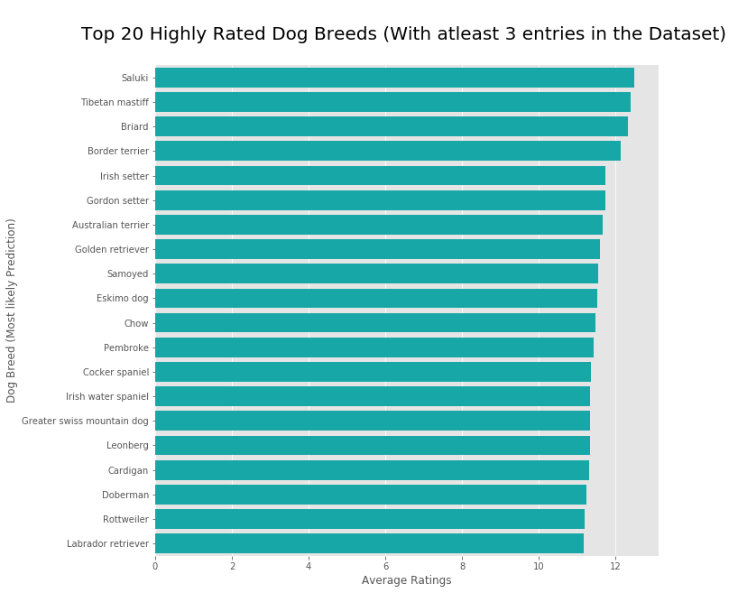

```python
# Initialize the matplotlib figure
f, ax = plt.subplots(figsize=(10, 10))


# Plot top Breeds
sns.barplot(x='rating_numerator', y='pred_val', data=Dog_type.sort_values('rating_numerator',ascending=False).head(20),label="Average Rating",color ='c')
#sns.barplot(x='retweet_count', y='pred_val', data=Dog_type.sort_values('retweet_count',ascending=False),label="retweet count")


#formatting and labels
ax.set_title('\nTop 20 Highly Rated Dog Breeds (With atleast 3 entries in the Dataset) \n',fontsize=20)
ax.set(xlabel="Average Ratings", ylabel="Dog Breed (Most likely Prediction)")
sns.despine(left=True, bottom=True)
```

### "Saluki" is the highest rated dog breed on WeRateDogs, closely followed by Tibetan Mastiff.

###### PS: Dog Breeds with atleast 3 entries have been considered for this Analysis. Also, Dog breen is a predicted value so, it maynot be 100% accurate and many of the tweets in the smaple set doesn;t have a predicted value.

## Find out wheather the popularity of WeRateDogs increasing over time or not.

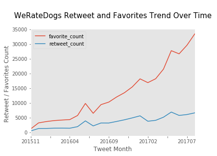

```python
Retweet_trend = twitter_data_final[["timestamp","favorite_count","retweet_count"]].groupby("timestamp").mean().reset_index()
Retweet_trend['mnth_yr'] = Retweet_trend['timestamp'].apply(lambda x: x.strftime('%Y%m'))


plt.style.use('ggplot')
#plt.figure( figsize=(250,180) )

# Plot top Movies
Retweet_trend.groupby(['mnth_yr']).mean().plot.line()


#formatting and labels
plt.title('\n WeRateDogs Retweet and Favorites Trend Over Time \n',fontsize=15)


plt.xlabel('Tweet Month')
plt.ylabel('Retweet / Favorites Count ')
plt.grid(False)
```